# trial_1-test-Copy1

## Step 3: Test a Model on New Images

To give yourself more insight into how your model is working, download at least five pictures of German traffic signs from the web and use your model to predict the traffic sign type.

You may find `signnames.csv` useful as it contains mappings from the class id (integer) to the actual sign name.

### Load and Output the Images

```
Progress: 0.00%
Progress: 50.00%
```

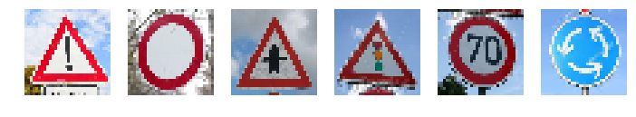

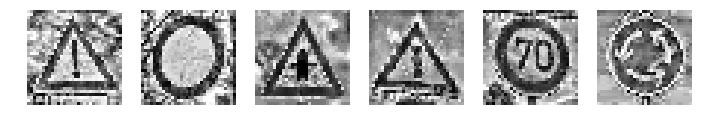

```python
def convertRGBtoY(x):
    x = 0.299 * x[:,:,:,0] + 0.587 * x[:,:,:,1] + 0.114 * x[:,:,:,2]
    x = (x / 255.).astype(np.float32)
    return x

def equalize_hist(x):
    from skimage import exposure
    import os
    imgs = np.empty([0,x.shape[1],x.shape[2],1], dtype=x.dtype)
    for i in range(len(x)):
        img = exposure.equalize_adapthist(x[i])
        img.shape = (1, img.shape[0], img.shape[1], 1)
        imgs = np.append(imgs,img,axis=0)
        if (i/len(x)*100) % 10 == 0:
            print('Progress: {:.2f}%'.format(i/len(x)*100))
    return imgs

### Load the images and plot them here.
### Feel free to use as many code cells as needed.
from PIL import Image
import numpy as np
import matplotlib.pyplot as plt

def load_image( infilename ) :
    img = Image.open( infilename )
    img.load()
    img = img.resize((32,32))
    data = np.asarray( img, dtype="uint8" )
    if data.shape[2] == 4:
        data = data[:,:,0:3]
    return data

n_new_images = 6
fig = plt.figure(figsize=(16,2))
test_imgs = np.empty([0,32,32,3])
for i in range(n_new_images):
    img = load_image('./new_images/{:d}.png'.format(i))
    ax = fig.add_subplot(np.ceil(n_new_images/8), 8, i+1)
    ax.axis('off')
    ax.imshow(img)
    img.shape = (1,32,32,3)
    test_imgs = np.append(test_imgs,img, axis=0)

test_imgs = convertRGBtoY(test_imgs)
test_imgs = equalize_hist(test_imgs)
plt.show()

test_labels = np.array([18,15,11,26,4,40])
fig = plt.figure(figsize=(16,2))
for i in range(len(test_imgs)):
    ax = fig.add_subplot(np.ceil(len(test_imgs)/8), 8, i+1)
    ax.axis('off')
    ax.imshow(test_imgs[i].squeeze(),cmap='gray')
plt.show()
```

### Predict the Sign Type for Each Image

```python
### Run the predictions here and use the model to output the prediction for each image.
### Make sure to pre-process the images with the same pre-processing pipeline used earlier.
### Feel free to use as many code cells as needed.
import csv
classes_string = []
with open('signnames.csv', newline='') as csvfile:
    rd = csv.reader(csvfile, delimiter=',', quotechar='|')
    i = 0
    for row in rd:
        if i==0:
            i += 1
            continue
        else:
            classes_string.append(row[1])

with tf.Session() as sess:
    sess.run(tf.global_variables_initializer())
    saver.restore(sess, './AdamOptimizer/model/final/model_epoch_30')

    for img in test_imgs:
        img.shape = (1,32,32,1)
        p = sess.run(logits,feed_dict={x: img, pred:False})
        print('class {:02d}: {:s}'.format(np.argmax(p[0]), classes_string[np.argmax(p[0])]))
```

```
class 18: General caution
class 15: No vehicles
class 11: Right-of-way at the next intersection
class 26: Traffic signals
class 04: Speed limit (70km/h)
class 40: Roundabout mandatory
```

### Analyze Performance

```python
### Calculate the accuracy for these 5 new images.
### For example, if the model predicted 1 out of 5 signs correctly, it's 20% accurate on these new images.
with tf.Session() as sess:
    sess.run(tf.global_variables_initializer())
    saver.restore(sess, './AdamOptimizer/model/final/model_epoch_30')
    validation_accuracy = evaluate(test_imgs, test_labels)
    print("Validation Accuracy = {:.3f} %".format(validation_accuracy * 100))
```

```
Validation Accuracy = 100.000 %
```

### Output Top 5 Softmax Probabilities For Each Image Found on the Web

For each of the new images, print out the model's softmax probabilities to show the **certainty** of the model's predictions (limit the output to the top 5 probabilities for each image). [`tf.nn.top_k`](https://www.tensorflow.org/versions/r0.12/api_docs/python/nn.html#top_k) could prove helpful here.

The example below demonstrates how tf.nn.top_k can be used to find the top k predictions for each image.

`tf.nn.top_k` will return the values and indices (class ids) of the top k predictions. So if k=3, for each sign, it'll return the 3 largest probabilities (out of a possible 43) and the correspoding class ids.

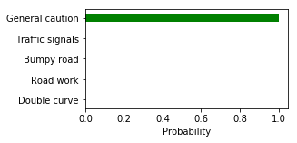

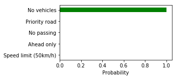

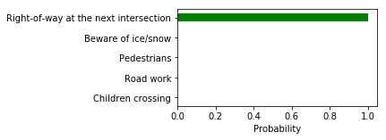

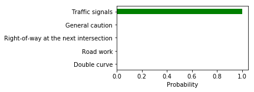

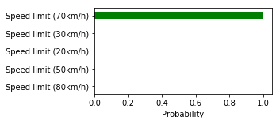

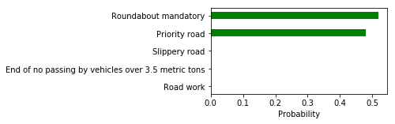

```python
### Print out the top five softmax probabilities for the predictions on the German traffic sign images found on the web.
### Feel free to use as many code cells as needed.
softmax = tf.nn.softmax(logits=logits)

with tf.Session() as sess:
    sess.run(tf.global_variables_initializer())
    saver.restore(sess, './AdamOptimizer/model/final/model_epoch_30')

    for img in test_imgs:
        img.shape = (1,32,32,1)
        p = sess.run(softmax,feed_dict={x: img, pred: False})
        prob = (tf.nn.top_k(p, k=5).values).eval()
        prob_idx = (tf.nn.top_k(p, k=5).indices).eval()

        # Example data
        fig, ax = plt.subplots()
        fig.set_size_inches(4, 2, forward=True)
        ts = (classes_string[prob_idx[0][0]],classes_string[prob_idx[0][1]],
              classes_string[prob_idx[0][2]],classes_string[prob_idx[0][3]],classes_string[prob_idx[0][4]])
        y_pos = np.arange(len(ts))

        ax.barh(y_pos, prob[0],height=0.4, align='center', color='green', ecolor='black')
        ax.set_yticks(y_pos)
        ax.set_yticklabels(ts)
        ax.invert_yaxis()  # labels read top-to-bottom
        ax.set_xlabel('Probability')

        plt.show()
```